# Understanding Polynomial Regression and Natural Splines in Tidymodels

Handling Non-Linear Relationships in Predictive Modelling

Author

Statistics for Big Data — MBG

Published

April 7, 2026

## 1 Introduction

When building predictive models we almost always begin with **linear regression**, which assumes the expected response increases or decreases in a straight-line way for every unit change in a predictor:

$$E[y \mid x] = \beta_0 + \beta_1 x$$

Many real-world relationships violate this assumption. The effect of age on blood pressure accelerates and then levels off; dose-response curves in pharmacology are sigmoidal; seasonal temperature patterns are periodic. Forcing a straight line through such data produces systematic errors (bias) that cross-validation will expose.

Two families of transformation address non-linearity whilst keeping the model **linear in its parameters** — which preserves interpretability, allows formal inference, and keeps the model compatible with a broad range of engines in tidymodels:

- **Polynomial basis expansions** — add powers of $x$ as extra predictors.
- **Splines** — fit piecewise polynomials joined smoothly at *knots*.

This document explains both approaches, connects the theory to the tidymodels functions `step_poly()` and `step_ns()`, and demonstrates how to compare and tune them using cross-validation.

## 2 Polynomial Regression

### 2.1 The model

A degree-$n$ polynomial regression model is

$$y = \beta_0 + \beta_1 x + \beta_2 x^2 + \beta_3 x^3 + \cdots + \beta_n x^n + \varepsilon$$

Although $y$ is a non-linear function of $x$, the model remains **linear in the parameters** $\beta_0, \ldots, \beta_n$. This means OLS estimation applies directly: we simply extend the design matrix $\mathbf{X}$ to include one column per power of $x$:

$$\mathbf{X} =
\begin{pmatrix}
1 & x_1 & x_1^2 & \cdots & x_1^n \\
1 & x_2 & x_2^2 & \cdots & x_2^n \\
\vdots & \vdots & \vdots & \ddots & \vdots \\
1 & x_N & x_N^2 & \cdots & x_N^n
\end{pmatrix}$$

The OLS estimate $\hat{\boldsymbol{\beta}} = (\mathbf{X}^\top \mathbf{X})^{-1} \mathbf{X}^\top \mathbf{y}$ then gives the fitted polynomial.

### 2.2 Limitations of high-degree polynomials

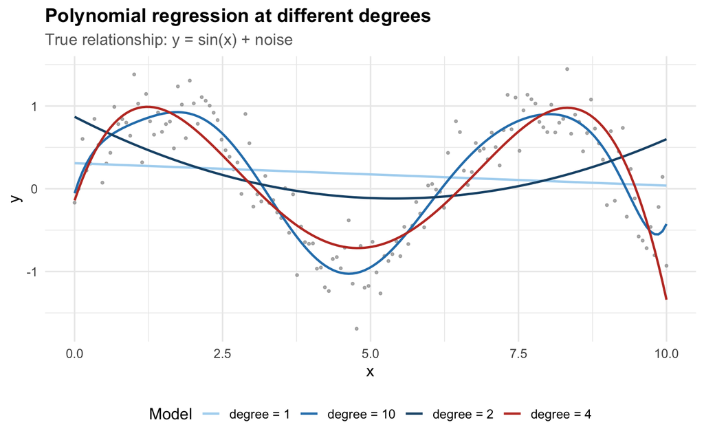

```r
set.seed(123)
n  <- 150
x  <- seq(0, 10, length.out = n)
y  <- sin(x) + rnorm(n, sd = 0.3)
dat <- data.frame(x = x, y = y)

# Fit polynomials of degree 1, 2, 4, 10
degrees <- c(1, 2, 4, 10)
preds   <- map_dfr(degrees, function(d) {
  fit   <- lm(y ~ poly(x, d, raw = FALSE), data = dat)
  data.frame(x = x, y_hat = fitted(fit), degree = paste0("degree = ", d))
})

ggplot(dat, aes(x, y)) +
  geom_point(colour = "grey60", size = 0.8, alpha = 0.7) +
  geom_line(data = preds, aes(x, y_hat, colour = degree), linewidth = 0.9) +
  scale_colour_manual(values = c("#AED6F1", "#2980B9", "#1A5276", "#C0392B"),
                      name   = "Model") +
  labs(title    = "Polynomial regression at different degrees",
       subtitle = "True relationship: y = sin(x) + noise",
       x = "x", y = "y")
```

**Degree 10 is dangerous**

### 2.3 Orthogonal polynomials and `step_poly()`

Raw polynomial columns ($x, x^2, x^3, \ldots$) are highly correlated, leading to numerical instability when inverting $\mathbf{X}^\top \mathbf{X}$. **Orthogonal polynomials** address this by using a basis where every column is uncorrelated with the others. This does not change the *shape* of the fitted curve — it only reparameterises the coefficients.

In tidymodels, `step_poly()` creates orthogonal polynomial features by default:

```r
# 1. Build a recipe with a degree-4 orthogonal polynomial
poly_recipe <- recipe(y ~ x, data = dat) |>
  step_poly(x, degree = 4)   # adds x_poly_1 ... x_poly_4

# 2. Prepare on training data (estimates column stats if needed)
poly_prep  <- prep(poly_recipe, training = dat)

# 3. Bake — apply transformation
poly_baked <- bake(poly_prep, new_data = dat)
head(poly_baked, 4)
```

```
# A tibble: 4 × 5
         y x_poly_1 x_poly_2 x_poly_3 x_poly_4
     <dbl>    <dbl>    <dbl>    <dbl>    <dbl>
1 -0.168     -0.140    0.179   -0.208    0.229
2 -0.00199   -0.139    0.172   -0.191    0.198
3  0.601     -0.137    0.165   -0.175    0.170
4  0.221     -0.135    0.158   -0.159    0.142
```

The original column `x` is replaced by four orthogonal basis functions `x_poly_1` through `x_poly_4`. The linear model fitted on these four columns corresponds exactly to a degree-4 polynomial.

## 3 Splines: Piecewise Polynomial Functions

### 3.1 The key idea

Rather than fitting one polynomial across the entire range of $x$, splines divide the range at **knots** $\xi_1 < \xi_2 < \cdots < \xi_K$ and fit a separate low-degree polynomial on each interval. The pieces are constrained to join smoothly at each knot.

**Why splines beat polynomials**

A global polynomial of degree 10 uses all of its flexibility to describe the whole range. A natural spline with, say, 5 knots uses only cubic pieces locally — it concentrates complexity where the data require it, and stays simple elsewhere. This gives lower variance without inflating bias.

### 3.2 The truncated power basis

A **cubic spline** with $K$ interior knots can be written in the truncated power basis:

$$f(x) = \underbrace{\beta_0 + \beta_1 x + \beta_2 x^2 + \beta_3 x^3}_{\text{global cubic}} + \sum_{k=1}^{K} b_k \underbrace{(x - \xi_k)_{+}^{3}}_{\text{knot term}}$$

where $(x - \xi_k)^3_+ = \max\{0, (x - \xi_k)^3\}$ is a function that equals zero to the left of knot $\xi_k$ and grows cubically to the right. The constraints ensuring smooth joins (continuity of $f$, $f'$, and $f''$ at each knot) are automatically satisfied by this basis. The total number of degrees of freedom is $K + 4$.

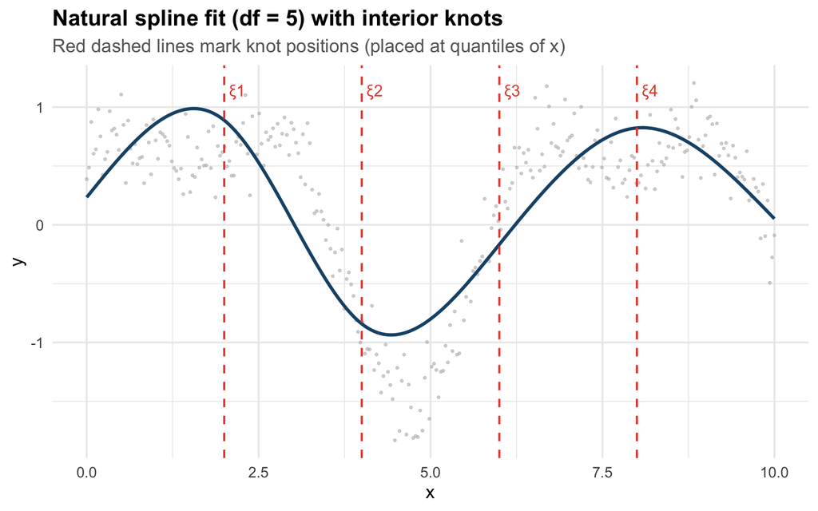

Figure 2: Knot placement illustrated. Knots (dashed lines) divide the range into intervals; within each interval the fit is locally cubic.

```r
# Demonstrate knot placement at quantiles
set.seed(123)
x_demo <- seq(0, 10, length.out = 300)
y_demo <- sin(x_demo) + 0.5 * cos(2 * x_demo) + rnorm(300, sd = 0.2)
d_demo <- data.frame(x = x_demo, y = y_demo)

spline_fit <- lm(y ~ ns(x, df = 5), data = d_demo)
knot_positions <- attr(ns(x_demo, df = 5), "knots")

d_demo$y_hat <- fitted(spline_fit)

ggplot(d_demo, aes(x, y)) +
  geom_point(colour = "grey70", size = 0.6, alpha = 0.5) +
  geom_line(aes(y = y_hat), colour = "#1A5276", linewidth = 1.1) +
  geom_vline(xintercept = knot_positions, linetype = "dashed",
             colour = "#E74C3C", linewidth = 0.7) +
  annotate("text", x = knot_positions, y = max(y_demo) * 0.95,
           label = paste0("ξ", seq_along(knot_positions)),
           colour = "#E74C3C", size = 4, hjust = -0.3) +
  labs(title    = "Natural spline fit (df = 5) with interior knots",
       subtitle = "Red dashed lines mark knot positions (placed at quantiles of x)",
       x = "x", y = "y")
```

### 3.3 Natural splines and boundary stability

An unconstrained cubic spline can still oscillate near the **boundary knots** (the outermost observed $x$ values), where there is little data to constrain the fit. A **natural spline** imposes two additional conditions:

$$f^{\prime\prime}(x) = 0 \quad \text{for } x < \xi_1 \quad \text{and} \quad f^{\prime\prime}(x) = 0 \quad \text{for } x > \xi_K$$

This forces the function to be **linear in the tails** — beyond the last observed $x$ on each side. Consequences:

- **Fewer df**: 2 constraints at each boundary → 4 fewer parameters overall.
- **Stable extrapolation**: linear tails are safer than extrapolated cubics.
- **Better bias-variance trade-off**: less variance at the edges of the data.

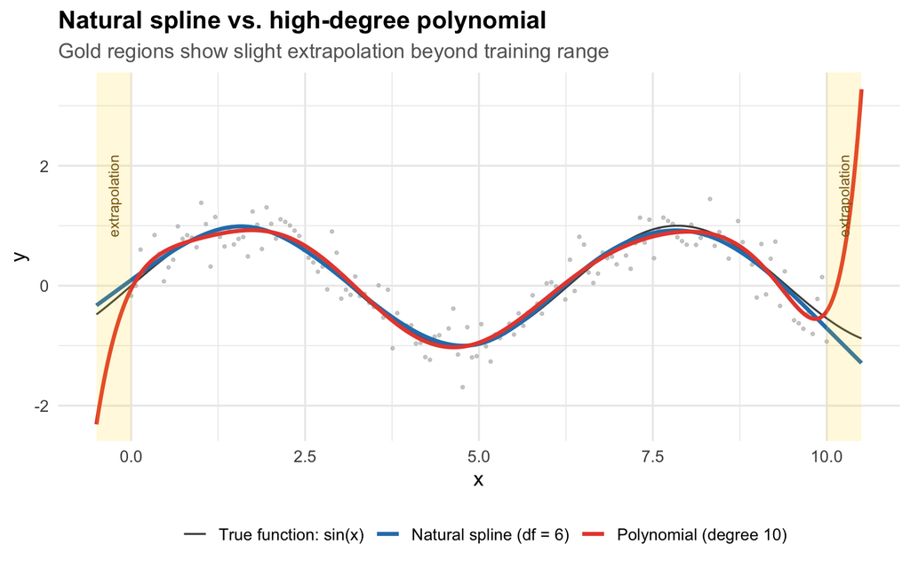

Figure 3: Natural spline (blue) vs. high-degree polynomial (red). The polynomial oscillates at the boundaries; the natural spline remains linear there.

```r
fit_ns   <- lm(y ~ ns(x, df = 6), data = dat)
fit_poly <- lm(y ~ poly(x, 10, raw = FALSE), data = dat)

# Extend x slightly beyond training range for extrapolation illustration
x_ext   <- seq(-0.5, 10.5, length.out = 400)
true_y  <- sin(x_ext)

pred_df <- data.frame(
  x     = x_ext,
  ns    = predict(fit_ns,   newdata = data.frame(x = x_ext)),
  poly  = predict(fit_poly, newdata = data.frame(x = x_ext)),
  truth = true_y
)

pred_long <- pivot_longer(pred_df, -x, names_to = "curve", values_to = "y_hat") |>
  mutate(curve = factor(curve,
    levels = c("truth", "ns", "poly"),
    labels = c("True function: sin(x)", "Natural spline (df = 6)", "Polynomial (degree 10)")))

ggplot() +
  geom_point(data = dat, aes(x, y), colour = "grey70", size = 0.7, alpha = 0.6) +
  geom_line(data = pred_long, aes(x, y_hat, colour = curve, linewidth = curve)) +
  scale_colour_manual(values = c("grey30", "#2980B9", "#E74C3C"), name = "") +
  scale_linewidth_manual(values = c(0.6, 1.2, 1.2), name = "") +
  annotate("rect", xmin = -0.5, xmax = 0, ymin = -Inf, ymax = Inf,
           fill = "gold", alpha = 0.15) +
  annotate("rect", xmin = 10, xmax = 10.5, ymin = -Inf, ymax = Inf,
           fill = "gold", alpha = 0.15) +
  annotate("text", x = -0.25, y = 1.5, label = "extrapolation", angle = 90,
           size = 3.2, colour = "goldenrod4") +
  annotate("text", x = 10.25, y = 1.5, label = "extrapolation", angle = 90,
           size = 3.2, colour = "goldenrod4") +
  labs(title    = "Natural spline vs. high-degree polynomial",
       subtitle = "Gold regions show slight extrapolation beyond training range",
       x = "x", y = "y")
```

## 4 The `step_ns()` Function in Recipes

### 4.1 What it does

`step_ns()` computes natural spline basis functions for a numeric predictor and adds them as new columns to the baked data frame. The original column is removed.

| Argument | Meaning |
| --- | --- |
| `x` (selector) | The column(s) to transform |
| `deg_free` | Degrees of freedom ($= K + 1$ for natural splines; each extra df adds one interior knot) |
| `knots` | Explicit interior knot positions (default: evenly-spaced quantiles) |
| `Boundary.knots` | Outer knot positions (default: range of training data) |

### 4.2 Under the hood

When you call `prep()` on a recipe containing `step_ns()`, the step:

1. **Estimates** knot positions from the *training data* (at evenly-spaced quantiles of the training $x$).
2. **Calls** `splines::ns()` internally to compute the basis matrix $\mathbf{B}(x)$.
3. **Stores** knot positions so that `bake()` applies the *identical* transformation to new data — preventing data leakage.

```r
# Recipe with natural spline (df = 4)
spline_recipe <- recipe(y ~ x, data = dat) |>
  step_ns(x, deg_free = 4)

spline_prep  <- prep(spline_recipe, training = dat)
spline_baked <- bake(spline_prep, new_data = dat)
head(spline_baked, 4)
```

```
# A tibble: 4 × 5
         y     x_ns_1   x_ns_2 x_ns_3  x_ns_4
     <dbl>      <dbl>    <dbl>  <dbl>   <dbl>
1 -0.168   0           0       0       0
2 -0.00199 0.00000322 -0.00680 0.0204 -0.0136
3  0.601   0.0000258  -0.0136  0.0408 -0.0272
4  0.221   0.0000871  -0.0204  0.0611 -0.0408
```

`x` has been replaced by `x_ns_1` through `x_ns_4`. A linear model fitted on these four columns produces a natural cubic spline with 4 df.

### 4.3 Visualising the basis functions

It is instructive to see what each basis function looks like. Each `x_ns_i` column is a smooth function of $x$ — the linear model’s job is to find the best weighted combination.

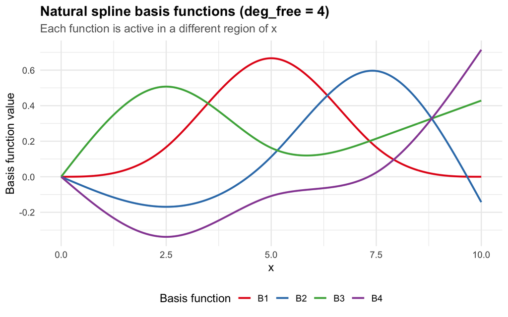

Figure 4: The four natural spline basis functions for deg_free = 4. The fitted spline is a weighted sum of these curves.

```r
# Extract basis matrix for visualisation
x_grid <- seq(0, 10, length.out = 300)
basis  <- ns(x_grid, df = 4)   # same as step_ns uses internally

basis_df <- as.data.frame(basis)
colnames(basis_df) <- paste0("B", 1:4)
basis_df$x <- x_grid

basis_long <- pivot_longer(basis_df, -x, names_to = "basis_fn", values_to = "value")

ggplot(basis_long, aes(x, value, colour = basis_fn)) +
  geom_line(linewidth = 1) +
  scale_colour_brewer(palette = "Set1", name = "Basis function") +
  labs(title    = "Natural spline basis functions (deg_free = 4)",
       subtitle = "Each function is active in a different region of x",
       x = "x", y = "Basis function value")
```

## 5 Worked Example: Full Tidymodels Workflow

We now put everything together: simulate non-linear data, build and compare three workflows (linear, polynomial, natural spline), and select the best model with cross-validation.

### 5.1 Data simulation

```r
set.seed(123)
n   <- 200
x   <- seq(0, 10, length.out = n)
y   <- sin(x) + rnorm(n, sd = 0.3)
dat_full <- data.frame(x = x, y = y)

# Train / test split (80/20)
split     <- initial_split(dat_full, prop = 0.8)
train_dat <- training(split)
test_dat  <- testing(split)

# 5-fold cross-validation on training data
set.seed(456)
folds <- vfold_cv(train_dat, v = 5)
```

### 5.2 Define recipes and workflows

```r
lm_spec <- linear_reg() |> set_engine("lm")

# Three recipes
linear_recipe <- recipe(y ~ x, data = train_dat)

poly_recipe   <- recipe(y ~ x, data = train_dat) |>
  step_poly(x, degree = 4)

spline_recipe <- recipe(y ~ x, data = train_dat) |>
  step_ns(x, deg_free = 4)

# Helper to build a workflow
make_wf <- function(rec) {
  workflow() |> add_recipe(rec) |> add_model(lm_spec)
}

linear_wf <- make_wf(linear_recipe)
poly_wf   <- make_wf(poly_recipe)
spline_wf <- make_wf(spline_recipe)
```

### 5.3 Cross-validate and compare RMSE

```r
cv_ctrl <- control_resamples(save_pred = TRUE)

linear_cv <- fit_resamples(linear_wf, folds, control = cv_ctrl)
poly_cv   <- fit_resamples(poly_wf,   folds, control = cv_ctrl)
spline_cv <- fit_resamples(spline_wf, folds, control = cv_ctrl)

results <- bind_rows(
  collect_metrics(linear_cv) |> mutate(model = "Linear"),
  collect_metrics(poly_cv)   |> mutate(model = "Poly degree-4"),
  collect_metrics(spline_cv) |> mutate(model = "Natural spline df=4")
) |>
  filter(.metric == "rmse") |>
  select(model, mean, std_err) |>
  arrange(mean)

results
```

```
# A tibble: 3 × 3
  model                mean std_err
  <chr>               <dbl>   <dbl>
1 Natural spline df=4 0.307  0.0203
2 Poly degree-4       0.338  0.0226
3 Linear              0.741  0.0574
```

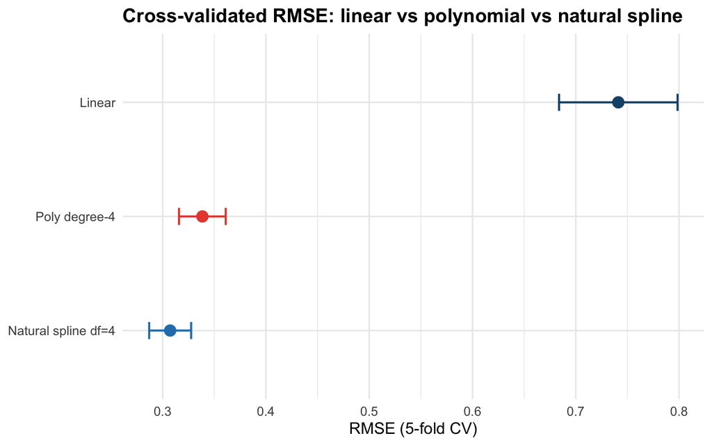

Figure 5: Cross-validated RMSE (mean ± 1 SE) for the three models. Lower is better.

```r
ggplot(results, aes(x = reorder(model, mean), y = mean, colour = model)) +
  geom_point(size = 4) +
  geom_errorbar(aes(ymin = mean - std_err, ymax = mean + std_err),
                width = 0.15, linewidth = 0.8) +
  scale_colour_manual(values = c("#1A5276", "#2980B9", "#E74C3C"), guide = "none") +
  coord_flip() +
  labs(title = "Cross-validated RMSE: linear vs polynomial vs natural spline",
       x     = NULL,
       y     = "RMSE (5-fold CV)")
```

### 5.4 Visual comparison of fitted curves

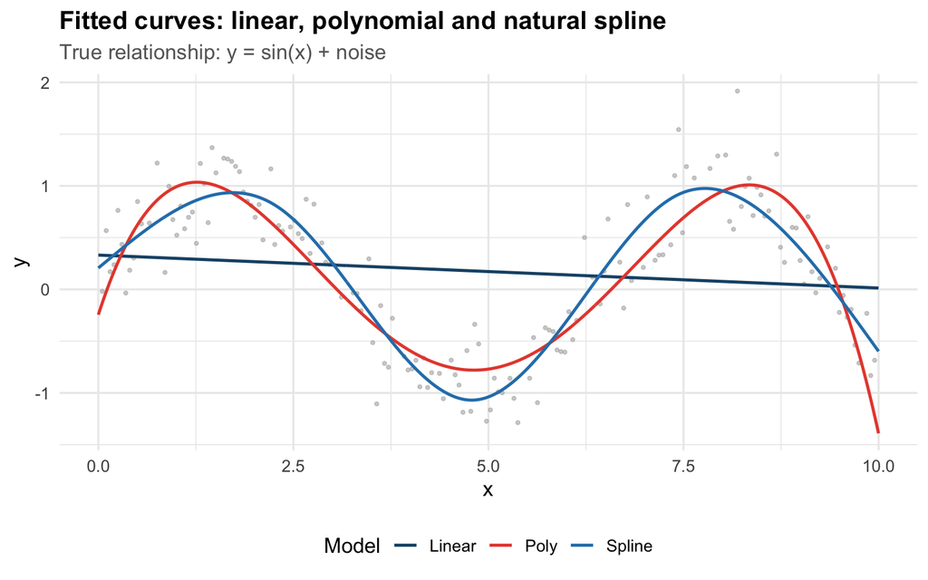

Figure 6: Fitted curves from all three models on the training data. The natural spline and polynomial both track the sinusoidal pattern; the linear model cannot.

```r
# Fit all three on full training data
linear_fit <- fit(linear_wf, data = train_dat)
poly_fit   <- fit(poly_wf,   data = train_dat)
spline_fit <- fit(spline_wf, data = train_dat)

# Predict on a dense grid
x_grid_df <- data.frame(x = seq(0, 10, length.out = 400))

fits_df <- data.frame(
  x      = x_grid_df$x,
  Linear = predict(linear_fit, new_data = x_grid_df)$.pred,
  Poly   = predict(poly_fit,   new_data = x_grid_df)$.pred,
  Spline = predict(spline_fit, new_data = x_grid_df)$.pred
) |>
  pivot_longer(-x, names_to = "model", values_to = "y_hat")

ggplot(train_dat, aes(x, y)) +
  geom_point(colour = "grey70", size = 0.8, alpha = 0.6) +
  geom_line(data = fits_df, aes(x, y_hat, colour = model), linewidth = 0.9) +
  scale_colour_manual(values = c("#1A5276", "#E74C3C", "#2980B9"), name = "Model") +
  labs(title    = "Fitted curves: linear, polynomial and natural spline",
       subtitle = "True relationship: y = sin(x) + noise",
       x = "x", y = "y")
```

## 6 Tuning the Degrees of Freedom

The choice of `deg_free` directly controls the flexibility of the natural spline. We can use `tune()` to search over a grid of values and select the one with the lowest cross-validated RMSE.

```r
# Recipe with deg_free as a tunable parameter
tune_recipe <- recipe(y ~ x, data = train_dat) |>
  step_ns(x, deg_free = tune())

tune_wf <- workflow() |>
  add_recipe(tune_recipe) |>
  add_model(lm_spec)

# Grid of df values to try
df_grid <- tibble(deg_free = 2:12)

# Tune over the CV folds
tune_res <- tune_grid(
  tune_wf,
  resamples = folds,
  grid      = df_grid,
  metrics   = metric_set(rmse, rsq)
)

show_best(tune_res, metric = "rmse", n = 5)
```

```
# A tibble: 5 × 7
  deg_free .metric .estimator  mean     n std_err .config
     <int> <chr>   <chr>      <dbl> <int>   <dbl> <chr>
1        6 rmse    standard   0.293     5  0.0212 Preprocessor05_Model1
2        7 rmse    standard   0.295     5  0.0201 Preprocessor06_Model1
3        8 rmse    standard   0.297     5  0.0205 Preprocessor07_Model1
4       10 rmse    standard   0.298     5  0.0200 Preprocessor09_Model1
5        5 rmse    standard   0.300     5  0.0171 Preprocessor04_Model1
```

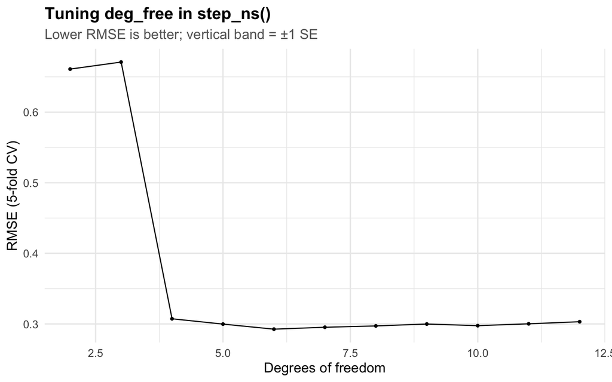

Figure 7: Cross-validated RMSE across a range of deg_free values for step_ns(). The minimum identifies the optimal complexity.

```r
autoplot(tune_res, metric = "rmse") +
  labs(title    = "Tuning deg_free in step_ns()",
       subtitle = "Lower RMSE is better; vertical band = ±1 SE",
       x        = "Degrees of freedom",
       y        = "RMSE (5-fold CV)") +
  scale_colour_manual(values = "#2980B9", guide = "none")
```

```r
# Finalise and evaluate on the held-out test set
best_df   <- select_best(tune_res, metric = "rmse")
final_wf  <- finalize_workflow(tune_wf, best_df)
final_fit <- last_fit(final_wf, split)

cat("Best deg_free:", best_df$deg_free, "\n")
```

```
Best deg_free: 6
```

```r
collect_metrics(final_fit)
```

```
# A tibble: 2 × 4
  .metric .estimator .estimate .config
  <chr>   <chr>          <dbl> <chr>
1 rmse    standard       0.288 Preprocessor1_Model1
2 rsq     standard       0.834 Preprocessor1_Model1
```

**Practical guidance on choosing deg_free**

- Start with `deg_free = 3` or `4`. This is the natural spline equivalent of “cubic” and is appropriate for most smooth but non-linear effects.
- Use `tune_grid()` to search `deg_free = 2:8`. Values above 6–8 rarely help and increase overfitting risk.
- **Never** select `deg_free` based on training RMSE alone — it will always decrease as df increases. Cross-validation is essential.

## 7 Why Use Splines in Predictive Modelling?

| Benefit | Explanation |
| --- | --- |
| Capture non-linearity | Polynomial and spline features let linear models follow curved relationships |
| Retain interpretability | The model is still linear in its parameters; coefficients and inference remain available |
| Stability at boundaries | Natural splines enforce linearity in the tails, reducing wild extrapolation |
| Local flexibility | Adding knots concentrates flexibility where it is needed, not globally |
| Better predictions | When the true relationship is non-linear, splines typically reduce RMSE substantially vs. a raw linear model |
| Easy to tune | `deg_free` is a single hyperparameter; `tune_grid()` makes selection straightforward |

## 8 Summary

- **Polynomial regression** is linear in the parameters but models curved relationships by including higher powers of $x$. Keep the degree $\leq 4$ to avoid boundary instability.
- **Regression splines** piece together low-degree (usually cubic) polynomials at knots. They concentrate flexibility locally and outperform global polynomials of comparable df.
- **Natural splines** add linearity constraints beyond the boundary knots ($f''(x) = 0$ for $x < \xi_1$ and $x > \xi_K$), reducing variance in the tails and improving stability.
- **`step_ns(x, deg_free = d)`** in a tidymodels recipe replaces $x$ with $d$ natural spline basis functions. Knot positions are estimated from the training data, ensuring no leakage.
- **`step_poly(x, degree = d)`** creates $d$ orthogonal polynomial features. Orthogonality improves numerical stability relative to raw powers.
- Use **`tune_grid()`** to select `deg_free` via cross-validation. A good starting range is 3–6.